title: “PA1_template.Rmd”

author: “Andres Yrigoyen”

date: “9/27/2020”

output: html_document

# Reproducible Research: Peer Assessment 1

This assignment makes use of data from a personal activity monitoring device. This device collects data at 5 minute intervals through out the day. The data consists of two months of data from an anonymous individual collected during the months of October and November, 2012 and include the number of steps taken in 5 minute intervals each day. Data is already loaded in local project data base Directory was assigned at such database

## Question 1.Loading and preprocessing the data

It is required to show any code required for Loading and preprocessing the data Also Process/transform the data (if necessary) into a format suitable for your analysis

```r
activity <- read.csv("activity.csv", header=TRUE, na.strings = "NA")
```

Loading packages

```r
library(dplyr)
library(lubridate)
```

```r
library(ggplot2)
library(httpuv)
```

Cleaning up the date class

```r
activityperdate <- ymd(activity$date)
```

Removing NA values from data base

```r
activity_noNAs <- na.omit(activity)
```

data review and visualization

```r
summary(activity_noNAs)
```

```
##      steps            date              interval
##  Min.   :  0.00   Length:15264       Min.   :   0.0
##  1st Qu.:  0.00   Class :character   1st Qu.: 588.8
##  Median :  0.00   Mode  :character   Median :1177.5
##  Mean   : 37.38                      Mean   :1177.5
##  3rd Qu.: 12.00                      3rd Qu.:1766.2
##  Max.   :806.00                      Max.   :2355.0
```

```r
str(activity_noNAs)
```

```
## 'data.frame':    15264 obs. of  3 variables:
##  $ steps   : int  0 0 0 0 0 0 0 0 0 0 ...
##  $ date    : chr  "2012-10-02" "2012-10-02" "2012-10-02" "2012-10-02" ...
##  $ interval: int  0 5 10 15 20 25 30 35 40 45 ...
##  - attr(*, "na.action")= 'omit' Named int [1:2304] 1 2 3 4 5 6 7 8 9 10 ...
##   ..- attr(*, "names")= chr [1:2304] "1" "2" "3" "4" ...
```

```r
head(activity_noNAs)
```

```
##     steps       date interval
## 289     0 2012-10-02        0
## 290     0 2012-10-02        5
## 291     0 2012-10-02       10
## 292     0 2012-10-02       15
## 293     0 2012-10-02       20
## 294     0 2012-10-02       25
```

## Question 2. What is mean total number of steps taken per day?

1. Calculate the total number of steps taken per day

```r
activity_noNAs2 <- summarise(group_by(activity_noNAs,date),daily.step=sum(steps))
activity_noNAs2
```

```
## # A tibble: 53 x 2
##    date       daily.step
##    <chr>           <int>
##  1 2012-10-02        126
##  2 2012-10-03      11352
##  3 2012-10-04      12116
##  4 2012-10-05      13294
##  5 2012-10-06      15420
##  6 2012-10-07      11015
##  7 2012-10-09      12811
##  8 2012-10-10       9900
##  9 2012-10-11      10304
## 10 2012-10-12      17382
## # ... with 43 more rows
```

2. Make a histogram of the total number of steps taken each day Data preparation for ggplot

Histogram construction

```r
mean_activity <- as.integer(mean(activity_noNAs2$daily.step))
mean_activity
```

```
## [1] 10766
```

```r
median_activity <- as.integer(median(activity_noNAs2$daily.step))
median_activity
```

```
## [1] 10765
```

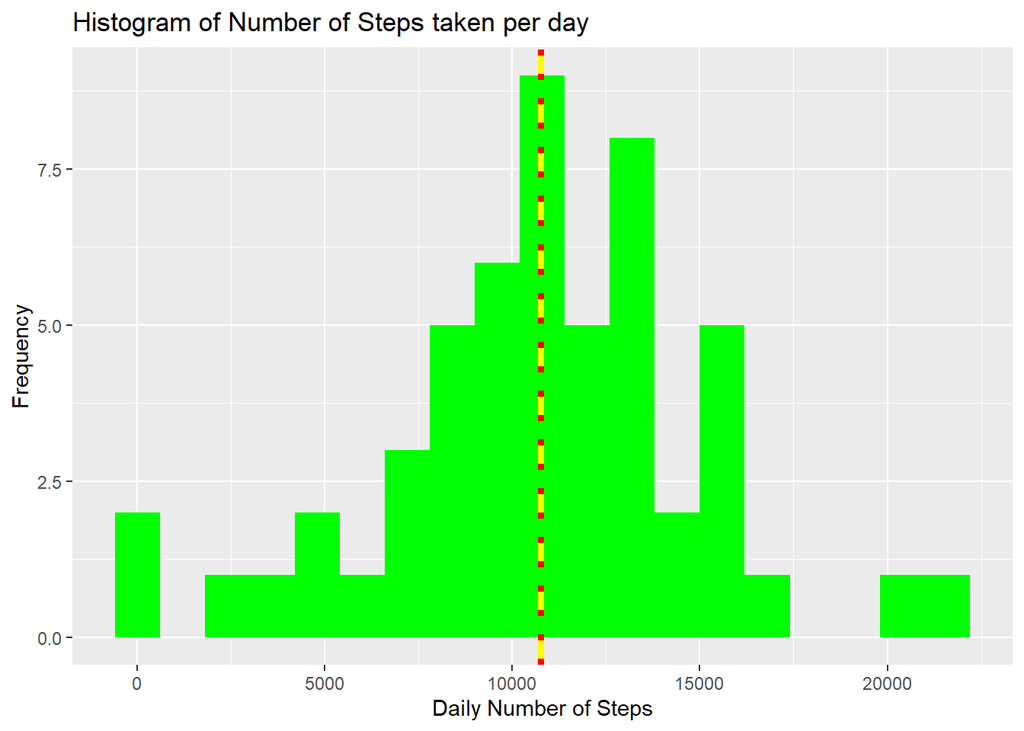

```r
steps_day_plot <- ggplot(activity_noNAs2, aes(x=daily.step)) +
    geom_histogram(binwidth = 1200, fill="green")    +
    geom_vline(xintercept=mean_activity, colour="yellow", linetype="dashed", size=1.5) +
    geom_vline(xintercept=median_activity, colour="red" , linetype="dotted", size=1.5) +
    labs(title="Histogram of Number of Steps taken per day", y="Frequency", x="Daily Number of Steps")
steps_day_plot
```

3. Calculate and report the mean and median of the total number of steps taken per day

### Mean total number of steps taken per day

```r
mean_activity <- as.integer(mean(activity_noNAs2$daily.step))
mean_activity
```

```
## [1] 10766
```

### Median total number of steps taken per day

```r
median_activity <- as.integer(median(activity_noNAs2$daily.step))
median_activity
```

```
## [1] 10765
```

### the mean total number of steps per day is 10766

### the median total number of steps per day is 10765

1.Make a time series plot (i.e. type = “l”) of the 5-minute interval (x-axis) and the average number of steps taken, averaged across all days (y-axis) Prepare data for plootting using ggplot

```r
activity_noNAs3 <- activity_noNAs %>% group_by(interval) %>% summarise(mean.step=mean(steps))
```

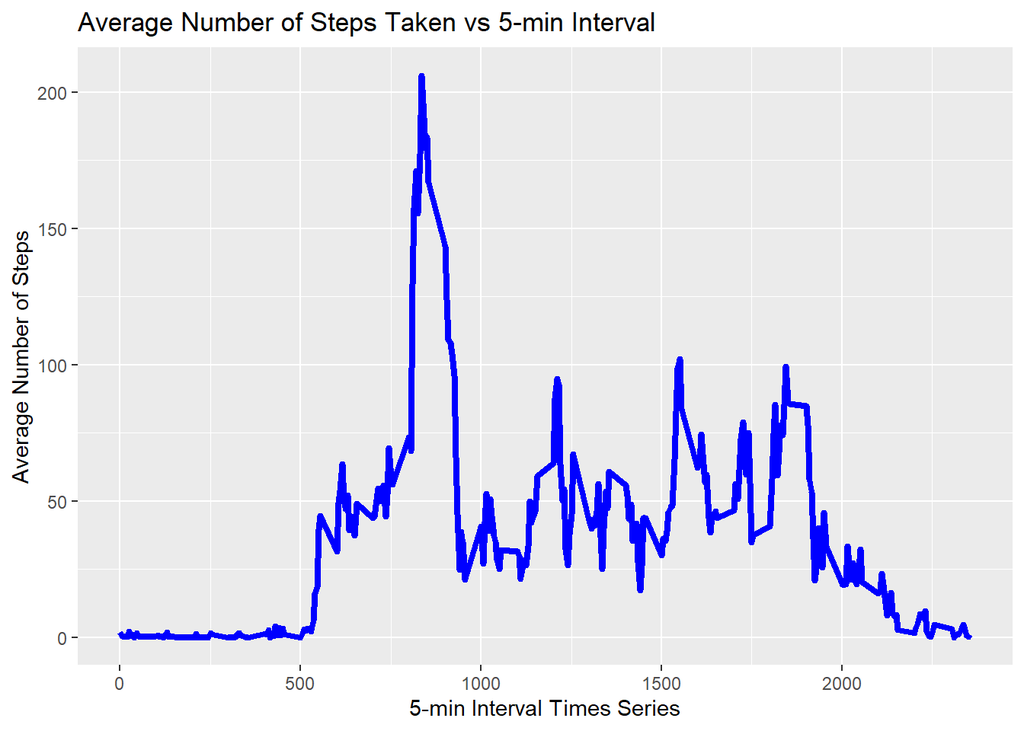

```r
plot_steps_perday <- ggplot(activity_noNAs3, aes(x=interval,y=mean.step)) +
    geom_line(color="blue", size=1.5) +
    labs(title="Average Number of Steps Taken vs 5-min Interval", y="Average Number of Steps", x="5-min Interval Times Series")
plot_steps_perday
```

2. Which 5-minute interval, on average across all the days in the dataset, contains the maximum number of steps?

```r
MaxStep_Int <- which.max(activity_noNAs3$mean.step)
MaxStep_Int_step <- activity_noNAs3$interval[MaxStep_Int]
sprintf("Maximum number of steps is found in the %gth 5-min interval", MaxStep_Int_step)
```

```
## [1] "Maximum number of steps is found in the 835th 5-min interval"
```

Note that there are a number of days/intervals where there are missing values (coded as NA). The presence of missing days may introduce bias into some calculations or summaries of the data.

1. Calculate and report the total number of missing values in the dataset (i.e. the total number of rows with NAs) the total number of missing values in the dataset can be compute by

```r
sum(is.na(activity))
```

```
## [1] 2304
```

##The answer is [1] 2304

2. Devise a strategy for filling in all of the missing values in the dataset. The strategy does not need to be sophisticated. For example, you could use the mean/median for that day, or the mean for that 5-minute interval, etc

```r
impute_na_activity <- activity
impute_na_activity$steps[is.na(impute_na_activity$steps)] <- mean(impute_na_activity$steps,na.rm=TRUE)
impute_na_activity$steps <- as.numeric(impute_na_activity$steps)
impute_na_activity$interval <- as.numeric(impute_na_activity$interval)
colSums(is.na(impute_na_activity))
```

```
##    steps     date interval
##        0        0        0
```

3. Create a new dataset that is equal to the original dataset but with the missing data filled in.

```r
summary(impute_na_activity)
```

```
##      steps            date              interval
##  Min.   :  0.00   Length:17568       Min.   :   0.0
##  1st Qu.:  0.00   Class :character   1st Qu.: 588.8
##  Median :  0.00   Mode  :character   Median :1177.5
##  Mean   : 37.38                      Mean   :1177.5
##  3rd Qu.: 37.38                      3rd Qu.:1766.2
##  Max.   :806.00                      Max.   :2355.0
```

4.Make a histogram of the total number of steps taken each day and Calculate and report the mean and median total number of steps taken per day. Do these values differ from the estimates from the first part of the assignment? What is the impact of imputing missing data on the estimates of the total daily number of steps?

```r
library(Hmisc)
impute_na_activity_noNAs2 <- summarise(group_by(impute_na_activity,date),daily.step=sum(steps))
mean_na_impute   <- as.integer(mean(impute_na_activity_noNAs2$daily.step))
mean_na_impute
```

```
## [1] 10766
```

```r
median_na_impute <- as.integer(median(impute_na_activity_noNAs2$daily.step))
median_na_impute
```

```
## [1] 10766
```

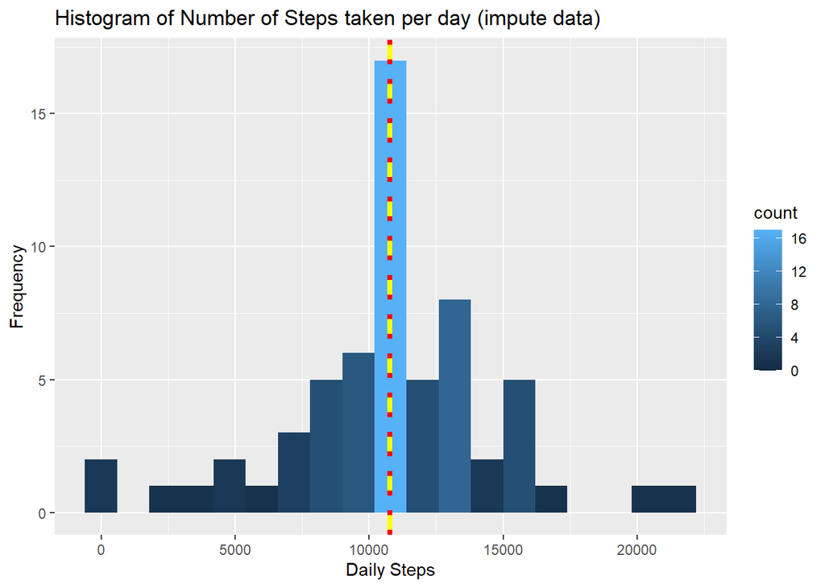

```r
steps_day_hist <- ggplot(impute_na_activity_noNAs2, aes(x=daily.step)) +
    geom_histogram(binwidth = 1200, aes(y=..count.., fill=..count..)) +
    geom_vline(xintercept=mean_na_impute, colour="yellow", linetype="dashed", size=1.5) +
    geom_vline(xintercept=median_na_impute, colour="red" , linetype="dotted", size=1.5) +
    labs(title="Histogram of Number of Steps taken per day (impute data)", y="Frequency", x="Daily Steps")
steps_day_hist
```